# Gesamtauswertung der Zyklen 1-6 der Legierung MC2

Stephan Rietzler

# Viscosity

## Graphische Analyse

In folgendem Plot sind die ermittelten Viskositäts-Wert gegen die Temperatur aufgetragen. Zusätzlich eingezeichnet ist ein in der Temperatur linearer und quadratischer Fit an die Daten.

**Folgerung:**

- Der Zusammenhang zwischen Viskosität und Temperatur scheint bei der Legierung MC2 durch den quadratischen Fit besser beschrieben zu sein. Bei Temperaturen deutlich über dem Schmelzpunkt nimmt die Viskosität mit abnehmenden Temperaturen nur wenig zu. Ab dem Schmelzpunkt scheint die Viskositätszunahme mit abnehmender Temperatur deutlich größer.
- Etwas vom allgeimnen Trend abzuweichen scheinen die Viskositäts-Daten der Axialkamera aus Zyklus 6. Da in der Kontrolle der Daten in der Auswertungs-Software kein offensichtlicher Grund hierfür zu erkenne ist werden sie in der weiteren Analyse nicht ausgeschlossen.
- Die als nicht plausible markierten Daten fallen nicht aus dem Trend. Aus Konsistenz-Gründen werden sie hier trotzdem von der weiteren Analyse ausgenommen.

## Numerische Analyse

Wie im Plot angedeutet wird wird ein linearer und ein quadratischer Fit durchgeführt um zu überprüfen ob die numerische Analyse die Vermutung eines nichtlinearen Zusammenhanges bestätigt.

**Anpassung einer linearen Funktion:**

**Anpassung einer quadratischen Funktion:**

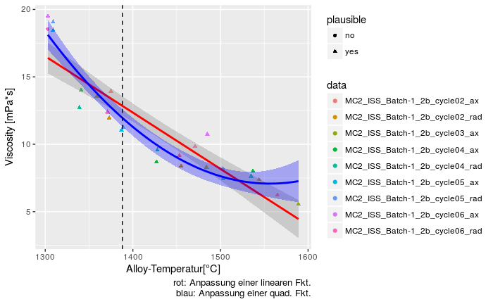

**Folgerung:**

Wie bereits vermutet beschreibt das Modell mit quadratischem Term die Daten besser was auf einen nichtlinearen Zusammenhang hindeutet. Damit bekommt man folgende Ergebnisse:

- Die Viskosität am Schmelzpunkt ist: $11.9 \ mPa\cdot s \pm 3 \cdot 0.3 \ mPa\cdot s$.
- Die Daten deuten auf einen nichtlinearen Zusammenhang zwischen Viskosität und Temperatur der Legierung MC2 hin.

# Surface-Tension

## Graphische Analyse

In der folgenden Graphik sind die ermittelten Oberflächenspannungen aus den (auswertbaren) Daten der ersten sechs Zyklen von MC2 dargestellt.

[output not shown]

**Folgerung:**

- Die graphische Darstellung legt die Vermutung nahe das die Oberflächenspannung bei MC2 nur wenig von der Temperatur abhängt.
- Erst bei Temperaturen deutlich überhalb des Schmelzpunktes scheint die Oberlächenspannung mit zunehmender Temperatur etwas abzunehmen.

## Numerische Analyse

Auch hier wird wieder ein lineares und quadratisches Modell gefittet um zu untersuchen ob der Zusammenahng zwischen Oberflächenspannung und Temperatur durch ein nichtlineares Modell besser beschrieben wird.

**Anpassung einer linearen Funktion**

[output not shown]

**Anpassung einer quadratischen Funktion**

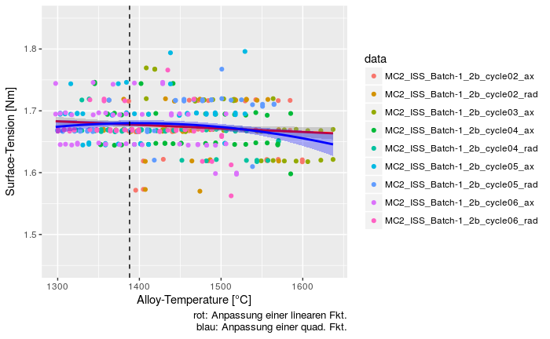

# Anhang: Summary der verwendeten Datensätze

- In der Auswertungssoftware gesetzte Parameter und dort vermerkte Kommentare zur Auswertung sind in den folgenden Abschnitten für jeden untersuchten Datensatz aus den Zyklen 1-6 gelistet.
- Die verwendeten Rohdaten (Ergebnisse aus der Auswertungssoftware) sind als csv Dateien anghängt.

**Bemerkung**

## Summary for MC2_ISS_Batch-1_2b_cycle02_ax

*Sample-Specification:*

- Alloy: MC2
- m: 1.225g
- radius: 3.246mm
- Melt.-Temp: 1388.0°C

*Experimental Design: (times are in seconds from start of recording)*

- Max. measured Temp. of alloy: 1643.0°C
- Measured Temp. at solidification of alloy: 1339.0°C
- End of Heatphase to time of solidification: (18.1059, 32.026)
- Data-Evaluation-Range: (19.0, 30.0)
- Temp-Span: (1643.0, 1339.0)
- Heat-pulse-Times at: 23/27
- Temp. at Heat-Pulse-Times: 1500.0/1417.0

*Evaluation Parameters:*

- Set Bandpass: Low: 5.0Hz, High: 75.0Hz
- Set smoothing of spectrogramm: smooth = 2, i.e. running mean over 5 adjacent periodogram ordinates
- Set amplitude-fraction: 95.0%
- Set time-window-size: 1.0s
- Set time-window-overlap: 50.0%
- Variables used for evaluation: A_RadiusX, A_RadiusY
- Time-Intervalls excluded from evaluation:

**Remarks:**

Bandpass bei 5Hz um niederfrequente Störung (hauptsächlich am Ende der Aufnahme) zu unterdrücken; Zuätzlich wird das signal am ende abgeschnitten.

am anfang wird 1s abgeschnitten wegen schlechtem sig/noise.

## Summary for MC2_ISS_Batch-1_2b_cycle02_rad

*Sample-Specification:*

- Alloy: MC2
- m: 1.225g
- radius: 3.246mm
- Melt.-Temp: 1388.0°C

*Experimental Design: (times are in seconds from start of recording)*

- Max. measured Temp. of alloy: 1599.0°C
- Measured Temp. at solidification of alloy: 1335.0°C
- End of Heatphase to time of solidification: (0.0, 12.8633)
- Data-Evaluation-Range: (0.0, 12.5)
- Temp-Span: (1599.0, 1335.0)
- Heat-pulse-Times at: 4/8
- Temp. at Heat-Pulse-Times: 1500.0/1418.0

*Evaluation Parameters:*

- Set Bandpass: Low: 5.0Hz, High: 200.0Hz
- Set smoothing of spectrogramm: smooth = 2, i.e. running mean over 5 adjacent periodogram ordinates
- Set amplitude-fraction: 95.0%
- Set time-window-size: 1.0s
- Set time-window-overlap: 50.0%
- Variables used for evaluation: R_RadiusX, R_RadiusY
- Time-Intervalls excluded from evaluation:

**Remarks:**

Kurz vor der Ende ist das signal von niederfrequentem Rauschen überlagert. Deswegen wird die Auswertung bei 12.5s abgebrochen und ein Hochpass von 5Hz gesetzt.

## Summary for MC2_ISS_Batch-1_2b_cycle03_ax

*Sample-Specification:*

- Alloy: MC2
- m: 1.225g
- radius: 3.246mm
- Melt.-Temp: 1388.0°C

*Experimental Design: (times are in seconds from start of recording)*

- Max. measured Temp. of alloy: 1651.0°C
- Measured Temp. at solidification of alloy: 1294.0°C
- End of Heatphase to time of solidification: (16.874, 34.0333)
- Data-Evaluation-Range: (16.9, 29.0)
- Temp-Span: (1651.0, 1294.0)
- Heat-pulse-Times at: 21/25
- Temp. at Heat-Pulse-Times: 1532.0/1444.0

*Evaluation Parameters:*

- Set Bandpass: Low: 5.0Hz, High: 75.0Hz
- Set smoothing of spectrogramm: smooth = 2, i.e. running mean over 5 adjacent periodogram ordinates
- Set amplitude-fraction: 95.0%
- Set time-window-size: 1.0s
- Set time-window-overlap: 50.0%
- Variables used for evaluation: A_RadiusX, A_RadiusY
- Time-Intervalls excluded from evaluation:

**Remarks:**

## Summary for MC2_ISS_Batch-1_2b_cycle03_rad

*Sample-Specification:*

- Alloy: MC2
- m: 1.225g
- radius: 3.246mm
- Melt.-Temp: 1388°C

*Experimental Design: (times are in seconds from start of recording)*

- Max. measured Temp. of alloy: 1648.0°C
- Measured Temp. at solidification of alloy: 1292.0°C
- End of Heatphase to time of solidification: (0.0, 17.2203)
- Data-Evaluation-Range: (0.0, 17.2203)
- Temp-Span: (1648.0, 1292.0)
- Heat-pulse-Times at: 4/8
- Temp. at Heat-Pulse-Times: 1533.0/1444.0

*Evaluation Parameters:*

- Set Bandpass: Low: 0.0Hz, High: 200.0Hz
- Set smoothing of spectrogramm: smooth = 2, i.e. running mean over 5 adjacent periodogram ordinates
- Set amplitude-fraction: 95.0%
- Set time-window-size: 1.0s
- Set time-window-overlap: 50.0%
- Variables used for evaluation: R_RadiusX, R_RadiusY
- Time-Intervalls excluded from evaluation:

**Remarks:**

keine Signale vorhanden

## Summary for MC2_ISS_Batch-1_2b_cycle04_ax

*Sample-Specification:*

- Alloy: MC2
- m: 1.225g
- radius: 3.246mm
- Melt.-Temp: 1388°C

*Experimental Design: (times are in seconds from start of recording)*

- Max. measured Temp. of alloy: 1616.0°C
- Measured Temp. at solidification of alloy: 1297.0°C
- End of Heatphase to time of solidification: (17.2721, 33.4203)
- Data-Evaluation-Range: (17.3, 33.4203)
- Temp-Span: (1616.0, 1297.0)
- Heat-pulse-Times at: 23/27
- Temp. at Heat-Pulse-Times: 1470.0/1393.0

*Evaluation Parameters:*

- Set Bandpass: Low: 5.0Hz, High: 75.0Hz
- Set smoothing of spectrogramm: smooth = 2, i.e. running mean over 5 adjacent periodogram ordinates
- Set amplitude-fraction: 95.0%
- Set time-window-size: 1.0s
- Set time-window-overlap: 50.0%
- Variables used for evaluation: A_RadiusX, A_RadiusY
- Time-Intervalls excluded from evaluation:

**Remarks:**

## Summary for MC2_ISS_Batch-1_2b_cycle04_rad

*Sample-Specification:*

- Alloy: MC2
- m: 1.225g
- radius: 3.246mm
- Melt.-Temp: 1388°C

*Experimental Design: (times are in seconds from start of recording)*

- Max. measured Temp. of alloy: 1613.0°C
- Measured Temp. at solidification of alloy: 1296.0°C
- End of Heatphase to time of solidification: (0.0, 16.031)
- Data-Evaluation-Range: (1.0, 15.0)
- Temp-Span: (1613.0, 1296.0)
- Heat-pulse-Times at: 6/10
- Temp. at Heat-Pulse-Times: 1470.0/1393.0

*Evaluation Parameters:*

- Set Bandpass: Low: 10.0Hz, High: 100.0Hz
- Set smoothing of spectrogramm: smooth = 2, i.e. running mean over 5 adjacent periodogram ordinates
- Set amplitude-fraction: 95.0%
- Set time-window-size: 1.0s
- Set time-window-overlap: 50.0%
- Variables used for evaluation: R_RadiusX, R_RadiusY
- Time-Intervalls excluded from evaluation:

**Remarks:**

Datensatz scheint mit 200Hz gesamplet!? Am Anfang riesige Amplitude von RadiusY, deswegen Auswertung erst ab 1s. Wegen schlechtem sig/noise ratio wird am Ende 1s abgeschnitten

## Summary for MC2_ISS_Batch-1_2b_cycle05_ax

*Sample-Specification:*

- Alloy: MC2
- m: 1.225g
- radius: 3.246mm
- Melt.-Temp: 1388°C

*Experimental Design: (times are in seconds from start of recording)*

- Max. measured Temp. of alloy: 1592.0°C
- Measured Temp. at solidification of alloy: 1270.0°C
- End of Heatphase to time of solidification: (15.201, 32.503)
- Data-Evaluation-Range: (17.0, 31.0)
- Temp-Span: (1592.0, 1270.0)
- Heat-pulse-Times at: 22/27
- Temp. at Heat-Pulse-Times: 1432.0/1354.0

*Evaluation Parameters:*

- Set Bandpass: Low: 5.0Hz, High: 75.0Hz
- Set smoothing of spectrogramm: smooth = 2, i.e. running mean over 5 adjacent periodogram ordinates
- Set amplitude-fraction: 95.0%
- Set time-window-size: 1.0s
- Set time-window-overlap: 50.0%
- Variables used for evaluation: A_RadiusX, A_RadiusY
- Time-Intervalls excluded from evaluation:

**Remarks:**

Wegen schlechtem sig/noise wird am ende 1.5s abgeschnitten und ein Hochpass von 5Hz gesetzt.

Am Anfang werden 2s wegen schlechtem sig/noise abgeschnitten

## Summary for MC2_ISS_Batch-1_2b_cycle05_rad

*Sample-Specification:*

- Alloy: MC2
- m: 1.225g
- radius: 3.246mm
- Melt.-Temp: 1388°C

*Experimental Design: (times are in seconds from start of recording)*

- Max. measured Temp. of alloy: 1592.0°C
- Measured Temp. at solidification of alloy: 1271.0°C
- End of Heatphase to time of solidification: (0.0, 17.2408)
- Data-Evaluation-Range: (0.5, 17.2408)
- Temp-Span: (1592.0, 1271.0)
- Heat-pulse-Times at: 7/11
- Temp. at Heat-Pulse-Times: 1432.0/1354.0

*Evaluation Parameters:*

- Set Bandpass: Low: 5.0Hz, High: 200.0Hz
- Set smoothing of spectrogramm: smooth = 2, i.e. running mean over 5 adjacent periodogram ordinates
- Set amplitude-fraction: 95.0%
- Set time-window-size: 1.0s
- Set time-window-overlap: 50.0%
- Variables used for evaluation: R_RadiusX, R_RadiusY
- Time-Intervalls excluded from evaluation:

**Remarks:**

## Summary for MC2_ISS_Batch-1_2b_cycle06_ax

*Sample-Specification:*

- Alloy: MC2
- m: 1.225g
- radius: 3.246mm
- Melt.-Temp: 1388°C

*Experimental Design: (times are in seconds from start of recording)*

- Max. measured Temp. of alloy: 1568.0°C
- Measured Temp. at solidification of alloy: 1275.0°C
- End of Heatphase to time of solidification: (14.5459, 30.6903)
- Data-Evaluation-Range: (16.0, 30.0)
- Temp-Span: (1568.0, 1275.0)
- Heat-pulse-Times at: 21/26
- Temp. at Heat-Pulse-Times: 1416.0/1335.0

*Evaluation Parameters:*

- Set Bandpass: Low: 10.0Hz, High: 75.0Hz
- Set smoothing of spectrogramm: smooth = 2, i.e. running mean over 5 adjacent periodogram ordinates
- Set amplitude-fraction: 95.0%
- Set time-window-size: 1.0s
- Set time-window-overlap: 50.0%
- Variables used for evaluation: A_RadiusX, A_RadiusY
- Time-Intervalls excluded from evaluation:

**Remarks:**

Am Anfang werden 1.5s abgeschnitten wegen schlechtem sig/noise.

## Summary for MC2_ISS_Batch-1_2b_cycle06_rad

*Sample-Specification:*

- Alloy: MC2
- m: 1.225g
- radius: 3.246mm
- Melt.-Temp: 1388°C

*Experimental Design: (times are in seconds from start of recording)*

- Max. measured Temp. of alloy: 1537.0°C
- Measured Temp. at solidification of alloy: 1274.0°C
- End of Heatphase to time of solidification: (0.0, 15.1033)
- Data-Evaluation-Range: (0.0, 14.0)
- Temp-Span: (1537.0, 1274.0)
- Heat-pulse-Times at: 6/11
- Temp. at Heat-Pulse-Times: 1417.0/1335.0

*Evaluation Parameters:*

- Set Bandpass: Low: 10.0Hz, High: 200.0Hz
- Set smoothing of spectrogramm: smooth = 2, i.e. running mean over 5 adjacent periodogram ordinates
- Set amplitude-fraction: 95.0%
- Set time-window-size: 1.0s
- Set time-window-overlap: 50.0%
- Variables used for evaluation: R_RadiusX, R_RadiusY
- Time-Intervalls excluded from evaluation:

**Remarks:**

Signal ist von niederfrequenter störung überlagert. HP von 10Hz filtert diese Störung heraus.

Wegen schlechtem sig/noise wird am ende eine sekunde abgeschnitten